# BCB420 - Computational Systems Biology

A1: Dataset Selection and Initial Processing

Chloe Nichole Calica

# Load Libraries Used

In this report, four libraries were used for the initial processing of the dataset:

```r
library(GEOquery)
library(knitr)
library(edgeR)
library(biomaRt)
```

# Selecting an Expression Dataset

The dataset I chose has accession GSE194294 and it is basically about how exposure to *Borrelia burgdorferi*, the bacterium responsible for Lyme disease, affects gene expression and DNA methylation in human cells [5].

## Choosing this dataset

I wanted to work with a dataset that was not cancer-specific because I feel like cancer is very common and well-explored in the RNAseq field. Thus, I wanted to look at other datasets that may involve investigating uncommon conditions. I decided to search for Lyme Disease as I have previously worked with it. Surprisingly, there are some datasets available in GEO and after filtering as outlined by my workflow in my [journal entry on dataset selection](https://github.com/bcb420-2025/Chloe_Calica/wiki/Entry-3.2:-Dataset-Selection), I settled on GSE194294 as my final dataset because it:

- used human cell lines for the samples;
- had an intersting experiment setup were expression is measured based on exposure to *B. burgdorferi*;
- performed whole-genome RNAseq which means that sequencing targeted all genes instead of just a subset; and
- was a high quality experiment i.e. three replicates for each condition was utilized, performed on a mature platform (Illumina NovaSeq 6000 with SP flow cell), and was published recently (submitted on 2022 and published on 2024) [5].

## Dataset Overview

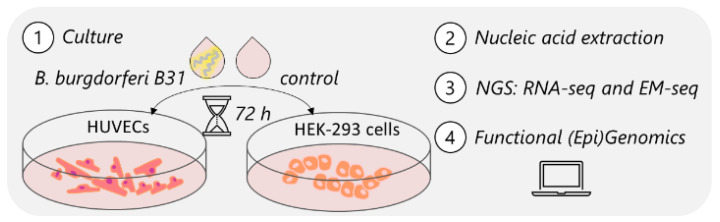

  **Figure 1. Experimental workflow for human cell models exposed to B. burgdorferi B31.** HUVECs and HEK-293 cells were exposed to B. burgdorferi B31 for 72 h. RNA and DNA were extracted and subjected to library preparation for next-generation sequencing (RNA-seq and enzymatic methyl-seq). Genome-wide epigenomic and transcriptomic data were used for functional enrichment analysis.

# Dataset Exploration

## Dataset Summary

```r
dataset_geoID <- "GSE194294"

gse <- getGEO(dataset_geoID, GSEMatrix=FALSE)
```

**Summary:** We used high-throughput sequencing to investigate the genome-wide transcriptional response in human cells to treatment with Borrelia burgdorferi. We chose a time point of 72 h as ticks feed on their host for several days and at the same time the early response in Lyme disease is expected to occur at this time period at a cellular level. We found that the two cell models studied (HUVEC and HEK-293 cells) had significantly different responses. More significantly differentially expressed genes (69 in total) were found in HUVEC cells than in HEK-293 cells (8 in total). Functional analysis indicated induction of the immune response in HUVEC and suggest changes in the extracellular matrix in HEK-293.

## Information about the Platform

```r
curr_gpl <- names(GPLList(gse))[1]
curr_gpl_info <- Meta(getGEO(curr_gpl))
```

- **Platform title:** Illumina NovaSeq 6000 (Homo sapiens)
- **Submission date:** Mar 02 2018
- **Last update date:** Nov 05 2018
- **Organism:** Homo sapiens
- **Number of GEO datasets that use this technology:** 18671
- **Number of GEO samples that use this technology:** 963881

## Information about the data and its processing

```r
gse@gsms[[1]]@header$data_processing
```

- adapter trimming with BaseSpace™ Sequence Hub Prep platform was followed by trimming with Trim Galore (v.0.4.4, Krueger, 2016) with default settings.
- pseudo alignment and quantification was performed with Salmon (v.1.4.0, Patro et al., 2017) in reference to the human transcriptome from Gencode (Release 37 - GRCh38.p13).
- Low-expressed genes were filtered out, and only genes with at least more than 1 read in at least 2 samples in one of the groups were considered for further analysis.
- normalization and differential expression of the count matrix was performed with DESeq2 (v.1.28.1, Love et al., 2014).
- Genome_build: hg19
- Supplementary_files_format_and_content: HUVEC_rawcounts.csv: Matrix table with raw counts for every gene and every HUVEC sample
- Supplementary_files_format_and_content: HEK-293_rawcounts.csv: Matrix table with raw counts for every gene and every HEK-293 sample
- Supplementary_files_format_and_content: BOTH_rawcounts.csv: Matrix table with raw counts for every gene and every cell type HUVEC and HEK-293

## Get the Expression Data File

```r
# Get supplementary files
supp_files <- getGEOSuppFiles(dataset_geoID, fetch_files = FALSE)
```

- GSE194294_BOTH_rawcounts.csv.gz
- GSE194294_HEK-293_rawcounts.csv.gz
- GSE194294_HUVEC_rawcounts.csv.gz

Notice that this info is also included in the last three bullet points of the previous section. The file names are straightforward (names of cell lines) and there is also a brief description about each one. They also indicated that this data is raw counts on gene level.

Use the dataset containing both cell lines: **GSE194294_BOTH_rawcounts.csv.gz**

```r
data_filename <- supp_files$fname[1]

# specify download location
download_dir <- file.path(getwd())

# check to see if file exists already before downloading
# only download files that we don't have
missing_files <- supp_files$fname[!unlist(
  lapply(supp_files$fname, FUN=function(x){
    file.exists(
      file.path(download_dir, dataset_geoID, x)
    )
  })
)]

# Get any files that are still missing
if(length(missing_files) > 0){
  for(i in 1:length(missing_files)){
    sfiles <- getGEOSuppFiles(dataset_geoID,
                              filter_regex = missing_files[i],
                              baseDir = download_dir,
                              fetch_files = TRUE)
  }
}
```

## Read the Data

Supplementary files had extension `csv.gz` so it is a compressed csv file which can be read using `read.csv()`

```r
# Read csv file
both_cells_data <- read.csv(
  file.path(download_dir, dataset_geoID, data_filename),
            header = TRUE,
            check.names = TRUE)

# get the dimensions
dim(both_cells_data)
```

```
## [1] 29351    13
```

```r
# Show a bit of the data
kable(head(both_cells_data))
```

| X | AB25 | AB26 | AB27 | AB28 | AB29 | AB30 | AB31 | AB32 | AB33 | AB34 | AB35 | AB36 |
| --- | --- | --- | --- | --- | --- | --- | --- | --- | --- | --- | --- | --- |
| ENSG00000118523.6 | 93838 | 82255 | 103598 | 1905 | 2062 | 1963 | 65707 | 73385 | 87141 | 3692 | 4150 | 4696 |
| ENSG00000148677.7 | 22706 | 19452 | 26285 | 349 | 400 | 382 | 15806 | 18219 | 20996 | 814 | 815 | 1039 |
| ENSG00000142871.18 | 34899 | 30824 | 40091 | 1683 | 1891 | 1779 | 26172 | 29339 | 32656 | 2820 | 2921 | 3186 |
| ENSG00000006327.14 | 2897 | 2597 | 3392 | 950 | 1043 | 1138 | 2341 | 2442 | 3250 | 1504 | 1689 | 1806 |
| ENSG00000167767.14 | 1567 | 1433 | 1739 | 174 | 159 | 197 | 1394 | 1513 | 1708 | 290 | 385 | 403 |
| ENSG00000111799.22 | 12135 | 10147 | 12346 | 2451 | 2783 | 2847 | 10102 | 13405 | 11704 | 3864 | 3959 | 4467 |

The dimensions of the data seem right. In the paper, they indicated that 26919 genes in HUVEC and 29367 in HEK-293 were found. Although this is not exactly the number of rows above, this is close enough as differences may simply be due to the merging of the two files together.

As for the columns, they indicated that there were 12 samples and this is exactly what we see in the table, with the 13th column being the gene Ensembl ids. However, the column names are in some sort of a code so we would have to get more information about them.

Since the Ensembl gene ids are in the column, we move change it to rownames instead so we dont’ have to account for it everytime we deal with the count data.

```r
# Set as rownames then delete column
rownames(both_cells_data) <- both_cells_data$X
both_cells_data$X <- NULL

# Check that we have removed it and set it as rownames
dim(both_cells_data)
```

```
## [1] 29351    12
```

```r
head(rownames(both_cells_data))
```

```
## [1] "ENSG00000118523.6"  "ENSG00000148677.7"  "ENSG00000142871.18"
## [4] "ENSG00000006327.14" "ENSG00000167767.14" "ENSG00000111799.22"
```

## Deciphering Column Names

Sample titles include the codes used in the column names and specifies the cell line and treatment undergone by each sample.

```r
gse@gsms[[1]]@header$title
```

```
## [1] "AB34: HEK-293 control 72 h - rep1"
```

Accessing GEO accession for each sample.

```r
gse@gsms[[1]]@header$geo_accession
```

```
## [1] "GSM5832723"
```

Additional information on each sample

```r
gse@gsms[[1]]@header$characteristics_ch1
```

```
## [1] "cell line: HEK-293"
## [2] "cell type: human embryonic kidney cells"
## [3] "treatment: unexposed"
```

## Collect Additional Annotation

```r
# Obtain all samples for this dataset
samples <- gse@gsms

# bind them together and gett the title and all the characteristics for each sample
sample_types <- do.call(rbind,
                        lapply(samples,
                               FUN=function(x){
                                 c(x@header$title,
                                   x@header$characteristics_ch1)

}))

# head(sample_types)
```

Clean up sample descriptions.

```r
colnames(sample_types) <- c("title", "cell line", "cell type", "treatment")

sample_types[, "cell line"] <- gsub(sample_types[, "cell line"],
                               pattern = "cell line: ",
                               replacement = "")

sample_types[, "cell type"] <- gsub(sample_types[, "cell type"],
                               pattern = "cell type: ",
                               replacement = "")

sample_types[, "treatment"] <- gsub(sample_types[, "treatment"],
                               pattern = "treatment: ",
                               replacement = "")

kable(sample_types)
```

|  | title | cell line | cell type | treatment |
| --- | --- | --- | --- | --- |
| GSM5832723 | AB34: HEK-293 control 72 h - rep1 | HEK-293 | human embryonic kidney cells | unexposed |
| GSM5832724 | AB35: HEK-293 control 72 h - rep2 | HEK-293 | human embryonic kidney cells | unexposed |
| GSM5832725 | AB36: HEK-293 control 72 h - rep3 | HEK-293 | human embryonic kidney cells | unexposed |
| GSM5832726 | AB28: HEK-293 Borr 72h - rep1 | HEK-293 | human embryonic kidney cells | exposed to Borrelia burgdorferi B31 for 72h |
| GSM5832727 | AB29: HEK-293 Borr 72h - rep2 | HEK-293 | human embryonic kidney cells | exposed to Borrelia burgdorferi B31 for 72h |
| GSM5832728 | AB30: HEK-293 Borr 72h - rep3 | HEK-293 | human embryonic kidney cells | exposed to Borrelia burgdorferi B31 for 72h |
| GSM5832729 | AB31: HUVEC control 72 h - rep1 | HUVEC | Human umbilical vein endothelial cells | unexposed |
| GSM5832730 | AB32: HUVEC control 72 h - rep2 | HUVEC | Human umbilical vein endothelial cells | unexposed |
| GSM5832731 | AB33: HUVEC control 72 h - rep3 | HUVEC | Human umbilical vein endothelial cells | unexposed |
| GSM5832732 | AB25: HUVEC Borr 72h - rep1 | HUVEC | Human umbilical vein endothelial cells | exposed to Borrelia burgdorferi B31 for 72h |
| GSM5832733 | AB26: HUVEC Borr 72h - rep2 | HUVEC | Human umbilical vein endothelial cells | exposed to Borrelia burgdorferi B31 for 72h |
| GSM5832734 | AB27: HUVEC Borr 72h - rep3 | HUVEC | Human umbilical vein endothelial cells | exposed to Borrelia burgdorferi B31 for 72h |

## Rename sample names

Since the initial sample names are in some sort of a code and not easily understandable, they will be changed to reflect the information presented in the previous table. This will make it easier to see the changes on between cell types and treatment without having to refer back to the table each time.

The names will be formatted this way: *cellLine_treatment#* where,

- `cellLine` is either HUVEC or HEC293
- `treatment` is either Borr for Borrelia burgdorferi exposure or Cont for control
- `#` : indicates which replicate number this sample is

```r
# AB25, 26, 27
colnames(both_cells_data)[1:3] <- paste0("HUVEC_", paste0("Borr", 1:3))

# AB28, 29, 30
colnames(both_cells_data)[4:6] <- paste0("HEK293_", paste0("Borr", 1:3))

# AB31, 32, 33
colnames(both_cells_data)[7:9] <- paste0("HUVEC_", paste0("Cont", 1:3))

# AB34, 35, 36
colnames(both_cells_data)[10:12] <- paste0("HEK293_", paste0("Cont", 1:3))

colnames(both_cells_data)
```

```
##  [1] "HUVEC_Borr1"  "HUVEC_Borr2"  "HUVEC_Borr3"  "HEK293_Borr1" "HEK293_Borr2"
##  [6] "HEK293_Borr3" "HUVEC_Cont1"  "HUVEC_Cont2"  "HUVEC_Cont3"  "HEK293_Cont1"
## [11] "HEK293_Cont2" "HEK293_Cont3"
```

# Data Cleanup

In this section, we look closely at the data and pre-process it before performing normalization.

## Data Type

As seen on the section in Information about the data and its processing, supplementary files are conveniently named with the `rawcounts.csv` extension which made it easy to determine that the data contains raw counts for every gene. To further confirm that it does contain gene level data, we look at the prefix in the rownames. The tables above show that the rownames all start with the prefix `ENSG` confirming that we were given gene level data.

## Initial Dataset Distributions

Here, we visualize the distribution of the dataset using different types of plots before doing any pre-processing.

### Boxplot

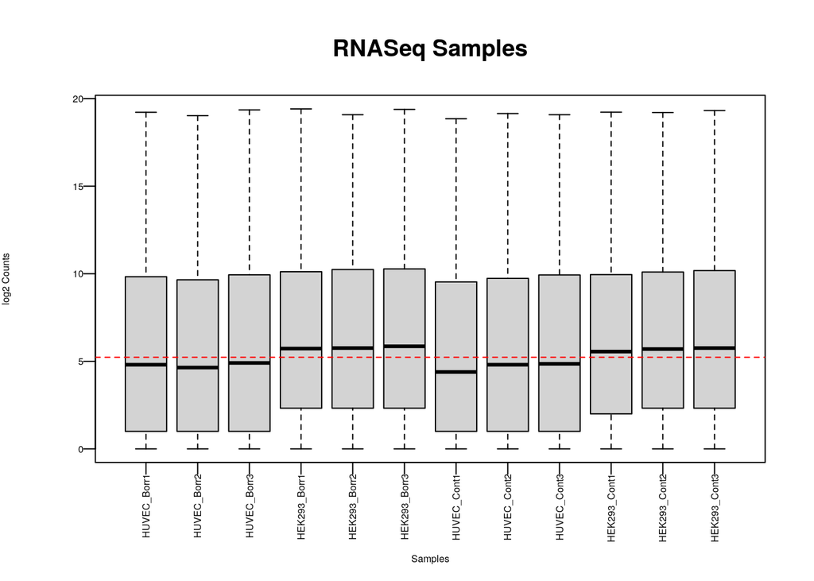

```r
create_boxplot <- function(log2_data){
  # Move x-axis title because it's being covered
  par(mgp=c(3.5, 0.5, 0))

  # Create boxplots
  boxplot(log2_data, xlab="Samples", ylab="log2 Counts",
          las=2, cex=0.5, cex.lab=0.5,
          cex.axis=0.5, main="RNASeq Samples")

  # Create median line
  abline(h=median(apply(log2_data, 2, median)),
         col="red", lwd=1, lty="dashed")
}

log2_data <- log2(both_cells_data)
create_boxplot(log2_data = log2_data)
```

**Figure 2: Initial boxplots of the dataset.** X-axis is the sample names while y-axis is the log2 transformed count of the data. The dashed red line indicates where the median is for all the samples.

Notice that there’s a warning (suppressed for the html) saying saying that “Outlier (-Inf) is not drawn.” This is expected because there are samples that have a raw count of 0 so when we got the log2 value of the data, these values became -Inf.

The median value for all datasets is around 5 and we observe that counts are similar within cell lines regardless of treatment while different between cell lines. In both Borr and Cont, HEK293 is above the median while HUVEC is below. There is some subtle difference between treatments but it is hard to tell just from these boxplots alone.

### Density Plot

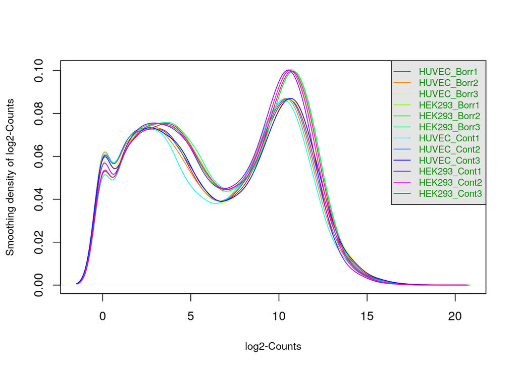

```r
create_density_plot <- function(count_density){
  # Calculate limits from all samples
  xlim <- 0; ylim <- 0
  for (i in 1:length(count_density)){
    xlim <- range(c(xlim, count_density[[i]]$x));
    ylim <- range(c(ylim, count_density[[i]]$y));
  }

  cols <- rainbow(length(count_density))
  ltys <- rep(1, length(count_density))

  # Plot first density to initialize plot
  plot(count_density[[1]], xlim=xlim, ylim=ylim, type="n",
       ylab="Smoothing density of log2-Counts",
       xlab="log2-Counts",
       main="", cex.lab=0.85)

  # Plot each line
  for (i in 1:length(count_density))
    lines(count_density[[i]], col=cols[i], lty=ltys[i])

  # Legend
  legend("topright", colnames(both_cells_data), col=cols, lty=ltys,
         cex=0.75, border="blue", text.col="green4", merge=TRUE, bg="gray90")
}

count_density1 <- apply(log2(both_cells_data), 2, density)
create_density_plot(count_density = count_density1)
```

**Figure 3: Initial density plot of the dataset.** X-axis is the log2 transformed counts while y-axis is the density. Each sample is colored differently from the rest.

Overall, the shape of the distribution is similar across all samples, but as we saw in the boxplots, cell lines cluster with each other i.e. HEK293 is generally shifted upwards (above the median in boxplots) while HUVEC falls below HEK293 (below median in boxplots). It is interesting to note, however, that around 0 to 0.25 of the x-axis, HUVEC is initially higher that HEK293 and then is distributed similarly before going below HEK293 for the rest of the plot.

## Filtering the Dataset

The section on Information about the data and its processing also shows information about how they filtered the dataset in the original study. They filtered lowly expressed genes and kept only those that have “at least more than 1 read in at least 2 samples in one of the groups.”

To replicate this, we set the minimal number of samples to 2 which makes sense given how the samples are set up for the experiment. There is a total of 12 samples and each sample type is always divided equally among all the samples.

- Cell Line: 6 HUVEC and 6 HEK293
- Treatment: 6 control and 6 Borrelia

In total, there are 4 conditions with 3 replicates each so essentially setting the minimal number of samples to 2 ensures that the genes we keep are found in the majority of the replicates per condition.

```r
min_num_samples <- 2

data_matrix <- as.matrix(both_cells_data)

# Create the group for each condition
cond_groups <- c("HUVEC_Borr", "HUVEC_Cont", "HEK293_Borr", "HEK293_Cont")

# convert raw counts to cpm
cpm_data <- cpm(both_cells_data)

# logical vector to keep track which genes to keep
keep <- rep(FALSE, nrow(both_cells_data))

# Loop through each group
for (i in cond_groups){
  # get all samples that belong to current group
  group_samples <- grep(paste0("^", i), colnames(both_cells_data))

  # Check if gene has cpm > 1 in at least 2 samples of the current group
  # the or condition here makes it so that we still keep the gene as long as it appears once across all the groups
  keep <- keep | rowSums(cpm_data[, group_samples] > 1) >= min_num_samples
}

# filter the dataset accdg to the keep vector
filtered_data_matrix <- data_matrix[keep, ]
```

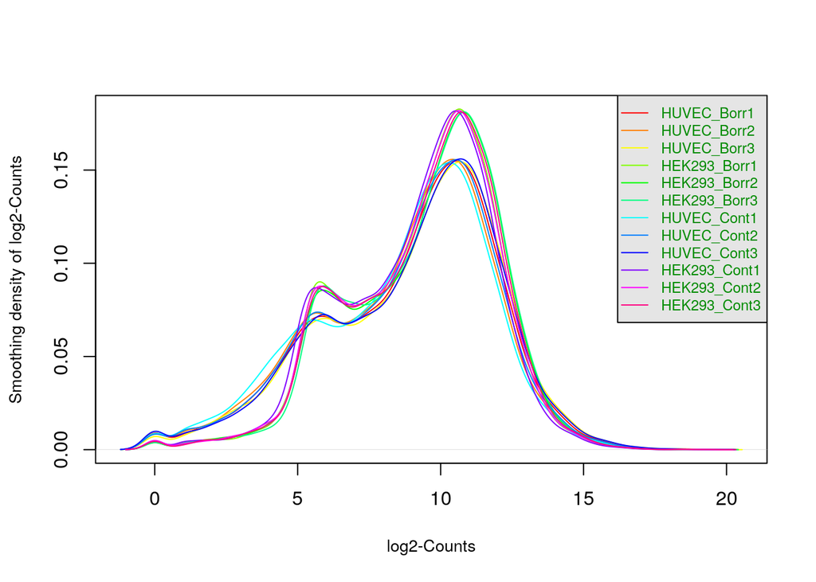

```r
count_density2 <- apply(log2(filtered_data_matrix), 2, density)

create_density_plot(count_density = count_density2)
```

**Figure 4: Density plot after filtering.** X-axis is the log2 transformed counts while y-axis is the density. Each sample is colored differently from the rest.

# Normalization

## Applying TMM to the dataset

Create an edgeR container and calculate normalization factors.

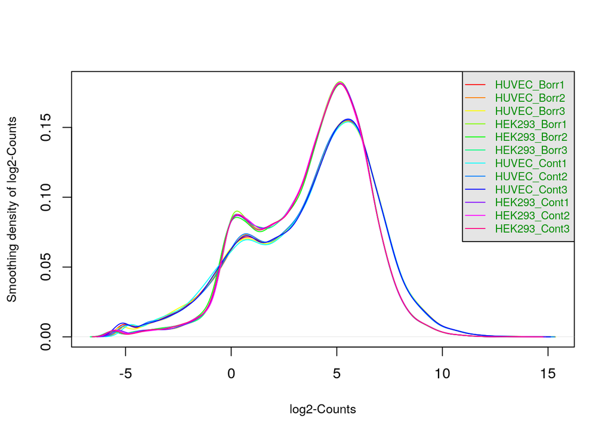

```r
# Convert sample_types to dataframe
sample_types <- as.data.frame(sample_types)

# edgeR container of class DGEList
d_container <- DGEList(counts = filtered_data_matrix, group = sample_types$treatment)

# Get normalization factors
d_container <- calcNormFactors(d_container)

# Convert to counts per million
normalized_counts <- cpm(d_container)

# Create density plot again
count_density3 <- apply(log2(normalized_counts), 2, density)
create_density_plot(count_density = count_density3)
```

**Figure 5: Density plot after normalization.** X-axis is the log2 transformed counts while y-axis is the density. Each sample is colored differently from the rest.

Distribution does not change that much but it gets smoothened out across all samples. We see a narrowing and clustering of the lines which means that we have tightened the distributions therefore making the samples more more comparable against each other.

We create boxplots again to look at the data’s distribution after normalization.

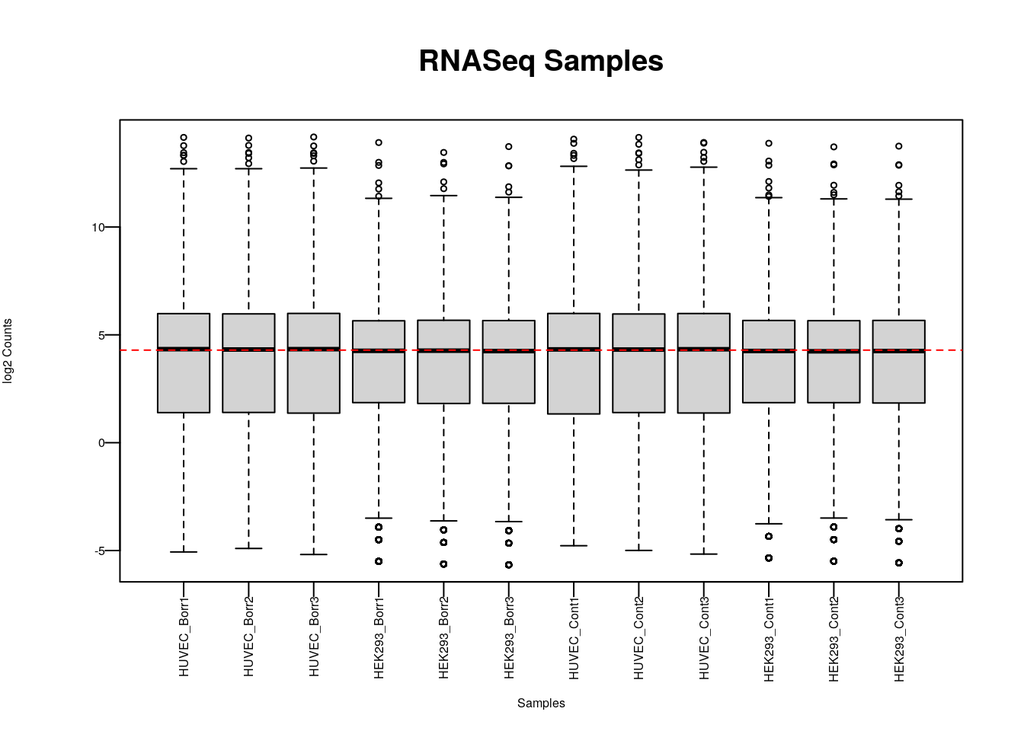

```r
log2_data2 <- log2(normalized_counts)
create_boxplot(log2_data = log2_data2)
```

**Figure 6: Boxplots of the dataset after normalization.** X-axis is the sample names while y-axis is the log2 transformed count of the data. The dashed red line indicates where the median is for all the samples.

From Figure 6, we see that the median for all samples are lined up in the median line, making the normalization a success. Furthermore, we see the same observations from Figure 2 where we observe that distribution of counts (quartiles) are similar within cell lines regardless of treatment while its different between cell lines. HUVEC has observably a wider quantile than HEK293.

## Outliers

Figure 6 shows that there are some outliers in the dataset, however, all of them are very close to the end of the boxlot’s whiskers so they are not totally off the distribution. Therefore, I decided not to exclude any of this datapoints because they might have only appeared due to biological variability.

Similarly, the original publication did not mention any outliers in their RNA-seq dataset. There was no mention of outliers in both the methods and the supplementary files so it is safe to assumed that they did not have any.

## Sample Separation by MDS

We do MDS after normalization to visualize the relationships between samples and assess how the data is separated based on the conditions we are interested in. This helps us separate samples based on biological variation rather than sequencing or technical biases.

There are two conditions of interest in this dataset: cell line and treatment.

### Cell Line

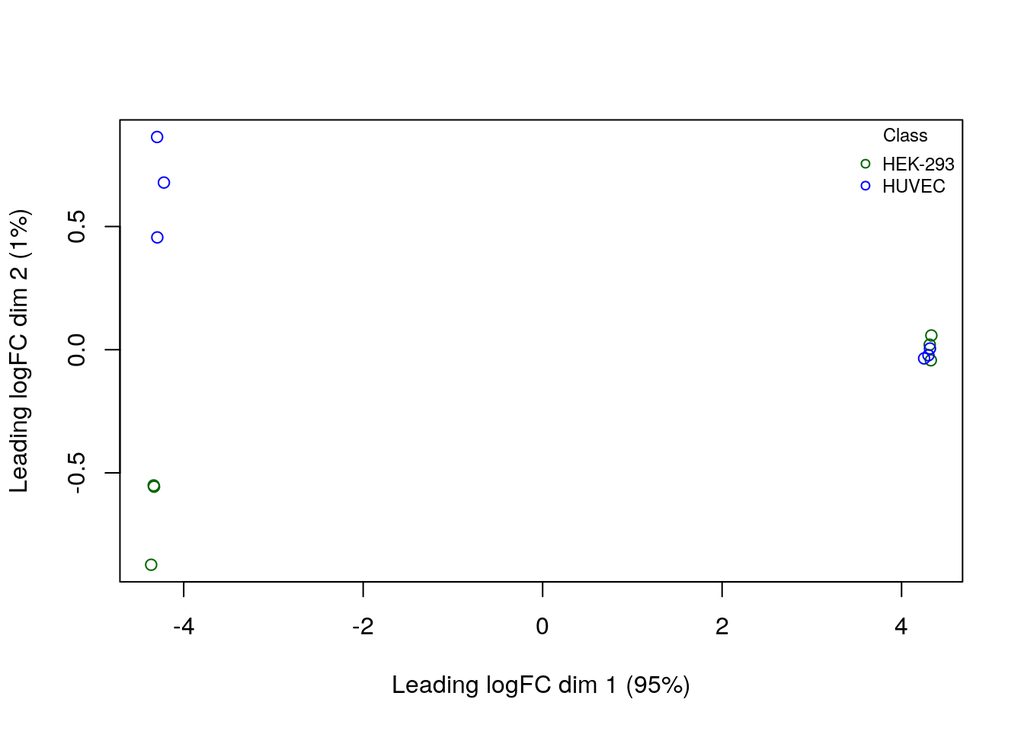

```r
limma::plotMDS(d_container, labels=NULL, pch = 1,
               col = c("darkgreen","blue")[factor(sample_types$`cell line`)])

legend("topright", legend=levels(factor(sample_types$`cell line`)), pch=c(1), col= c("darkgreen","blue"),title="Class", bty = 'n', cex = 0.75)
```

**Figure 7: MDS plot based on cell line.** X-axis represents 95% of the variance in the samples while the y-axis represents 1% of the variance.

### Treatment

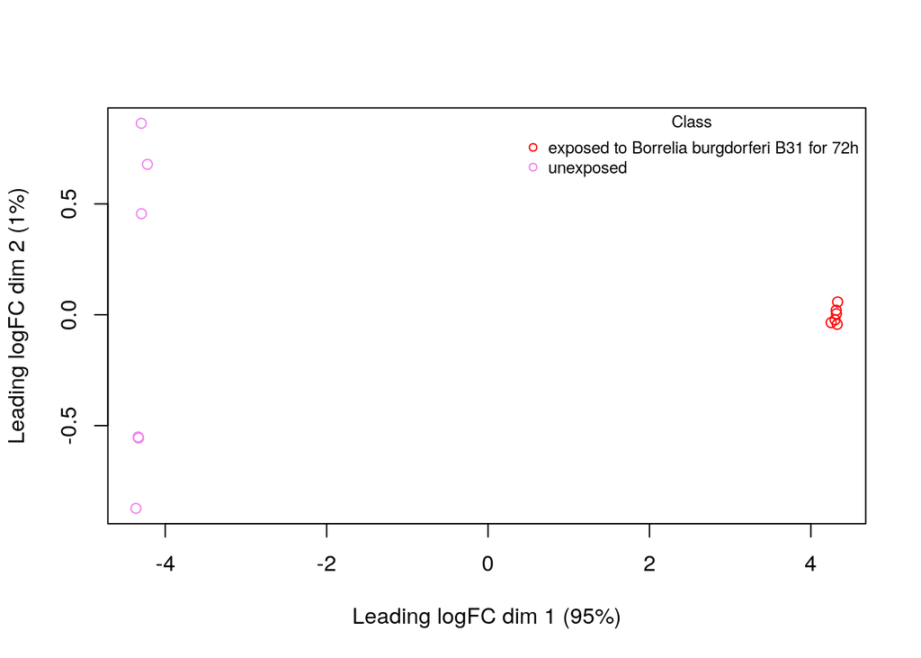

```r
limma::plotMDS(d_container, labels=NULL, pch = 1,
               col = c("red","violet")[factor(sample_types$`treatment`)])

legend("topright", legend=levels(factor(sample_types$`treatment`)), pch=c(1), col= c("red","violet"),title="Class", bty = 'n', cex = 0.75)
```

**Figure 8: MDS plot based on treatment.** X-axis represents 95% of the variance in the samples while the y-axis represents 1% of the variance.

## Dispersion

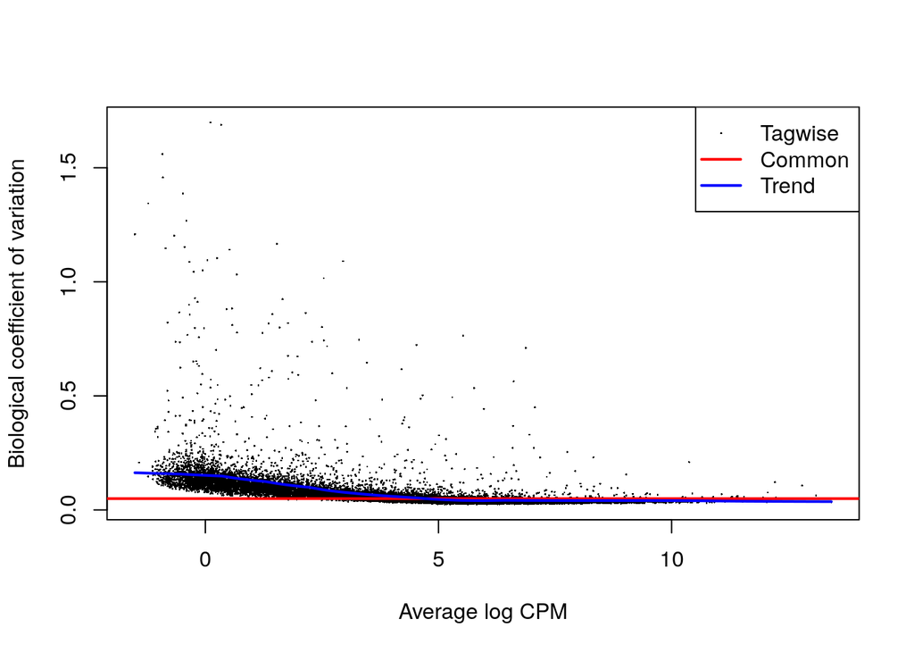

```r
model_design <- model.matrix(~sample_types$`cell line` + sample_types$treatment)
d_dispersion <- estimateDisp(d_container, model_design)
plotBCV(d_dispersion, col.tagwise = "black",col.common = "red",)
```

**Figure 9: BCV plot of the normalized data.** Tags or the black points in the plot represent individual genes. The blue trendline represents the general trend of gene dispersion while the red line shows the overall dispersion of the dataset.

The blue trendline on the BCV plot shows that the lowly expressed genes do show a higher biological variability than the highly expressed genes. However, there are only a few outliers and even with the lowly expressed genes, majority of them are below a BCV of 0.5. Additionally, the red line on the plot indicates that the overall variability of the dataset is very low and close to 0.0.

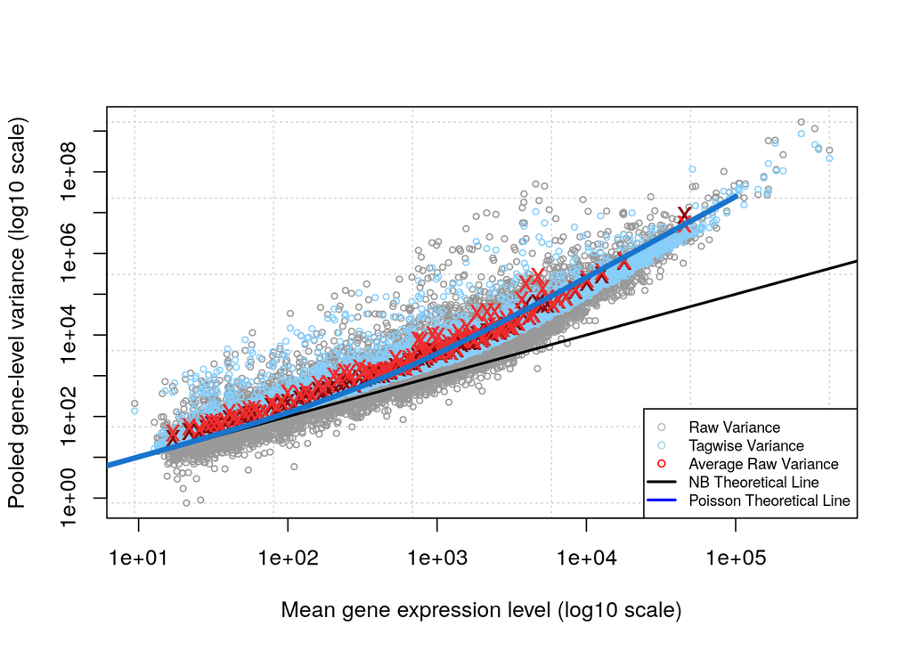

```r
plotMeanVar(d_dispersion, show.raw.vars = TRUE,show.tagwise.vars=TRUE,
            show.ave.raw.vars = TRUE, NBline=TRUE,
            show.binned.common.disp.vars = TRUE)

legend("bottomright",
       legend = c("Raw Variance", "Tagwise Variance", "Average Raw Variance",
                  "NB Theoretical Line", "Poisson Theoretical Line"),
       col = c("gray", "lightblue", "red", "black", "blue"),  # Colors matching the plot
       pch = c(1, 1, 1, NA, NA),  # Use points for variances, lines for the other two
       lty = c(NA, NA, NA, 1, 1),
       lwd = c(NA, NA, NA, 2, 2),
       cex = 0.7)
```

# Identifier Mapping

## Removing Version Numbers

Got rid of the version number for the associated ENSEMBL ids since the underlying gene doesn’t change regardless of the version number used.

```r
rownames(normalized_counts) <- unlist(lapply(rownames(normalized_counts),
                                            FUN=function(x){unlist(strsplit(x, split = "\\."))[1]}))

head(rownames(normalized_counts))
```

```
## [1] "ENSG00000118523" "ENSG00000148677" "ENSG00000142871" "ENSG00000006327"
## [5] "ENSG00000167767" "ENSG00000111799"
```

## Ensemble ID to HGNC Conversion

Access **biomaRt** [4] to obtain the HGNC symbols

```r
ensembl <- useDataset("hsapiens_gene_ensembl", mart=useMart("ensembl"))

ids2convert <- rownames(normalized_counts)

# check to see if id_coversion already exists because its
# computationally intensive
conversion_stash <- "id_conversion.rds"

if(file.exists(conversion_stash)){
  id_conversion <- readRDS(conversion_stash)
} else {
  id_conversion <- getBM(attributes = c("ensembl_gene_id","hgnc_symbol"),
                         filters = c("ensembl_gene_id"), values = ids2convert,
                         mart = ensembl)
  saveRDS(id_conversion, conversion_stash)
}
```

## Mapping Statistics

After mapping, we get the following values:

```r
num_mapped <- length(which(rownames(normalized_counts)
                           %in% id_conversion$ensembl_gene_id))
total <- nrow(normalized_counts)
```

- Number of genes we were able to map: 16497
- Total genes after normalization: 16620
- Difference: 123
- Percent Mapped: 99.2599278 %

```r
# Merge the identifiers into the normalized counts table
normalized_counts_annot <- merge(id_conversion, normalized_counts, by.x = 1,
                                 by.y = 0, all.y = TRUE)
kable(head(normalized_counts_annot))
```

| ensembl_gene_id | hgnc_symbol | HUVEC_Borr1 | HUVEC_Borr2 | HUVEC_Borr3 | HEK293_Borr1 | HEK293_Borr2 | HEK293_Borr3 | HUVEC_Cont1 | HUVEC_Cont2 | HUVEC_Cont3 | HEK293_Cont1 | HEK293_Cont2 | HEK293_Cont3 |
| --- | --- | --- | --- | --- | --- | --- | --- | --- | --- | --- | --- | --- | --- |
| ENSG00000000003 | TSPAN6 | 51.35769 | 48.827873 | 47.720061 | 47.4154532 | 49.478014 | 44.464244 | 52.394626 | 47.72035 | 51.821213 | 49.4400599 | 47.2328196 | 48.87348 |
| ENSG00000000419 | DPM1 | 29.60760 | 29.698049 | 30.382323 | 29.3829780 | 30.343542 | 30.150954 | 29.866762 | 27.71668 | 33.756383 | 29.9300811 | 26.3614702 | 30.11971 |
| ENSG00000000457 | SCYL3 | 10.09825 | 9.163587 | 8.999112 | 8.7175402 | 9.445618 | 8.116803 | 8.945424 | 10.03319 | 9.744398 | 8.5972002 | 8.2240674 | 7.82986 |
| ENSG00000000460 | FIRRM | 13.47430 | 12.976174 | 11.806174 | 31.7061803 | 33.161012 | 30.150954 | 14.422214 | 13.45074 | 11.922230 | 31.3834760 | 29.7622332 | 31.46678 |
| ENSG00000000971 | CFH | 94.76823 | 85.783215 | 98.027023 | 0.0663772 | 0.000000 | 0.000000 | 80.800911 | 83.74577 | 71.784666 | 0.0246338 | 0.0222272 | 0.00000 |
| ENSG00000001036 | FUCA2 | 95.72427 | 94.478589 | 96.953734 | 125.0104108 | 131.914344 | 125.553087 | 94.967541 | 94.18656 | 94.903181 | 143.5165864 | 137.3863803 | 146.83093 |

About 0.75% of genes was not mapped to a symbol. Since this is very little, we can simply omit these rows from the data.

```r
normalized_counts_annot <- normalized_counts_annot[!is.na(normalized_counts_annot$hgnc_symbol), ]
```

## Processing the Mappings

After mapping the Ensembl IDs to HGNC symbols, still need to account for special situations where one gene may map to multiple HGNC or different genes mapping to the same HGNC.

### One gene and multiple HGNC

We first look at genes that mapped to multiple HGNC symbols.

```r
unique(normalized_counts_annot$ensembl_gene_id[duplicated(normalized_counts_annot$ensembl_gene_id)])
```

```
## [1] "ENSG00000280739"
```

```r
normalized_counts_annot[normalized_counts_annot$ensembl_gene_id == "ENSG00000280739", ]
```

```
##       ensembl_gene_id hgnc_symbol HUVEC_Borr1 HUVEC_Borr2 HUVEC_Borr3
## 16268 ENSG00000280739   EIF1B-AS1    6.005174      4.8159    5.614125
## 16269 ENSG00000280739  ENTPD3-AS1    6.005174      4.8159    5.614125
##       HEK293_Borr1 HEK293_Borr2 HEK293_Borr3 HUVEC_Cont1 HUVEC_Cont2
## 16268     5.310177     5.574131     5.523386    5.075159    6.302097
## 16269     5.310177     5.574131     5.523386    5.075159    6.302097
##       HUVEC_Cont3 HEK293_Cont1 HEK293_Cont2 HEK293_Cont3
## 16268    6.645177     4.606523     4.467669     4.904187
## 16269    6.645177     4.606523     4.467669     4.904187
```

- Surprisingly, there is only one gene mapped to multiple symbols, so it was investigated further by going through the [HGNC](https://www.genenames.org/%5D) website to gather more information.
- According to [HGNC](https://www.genenames.org/%5D), EIF1B-AS1 is a “withdrawn symbol”while ENTPD3-AS1 is the approved symbol and we also see EIF1B-AS1 being listed as one of its previous names.
- Therefore, only the column with ENTPD3-AS1 is kept.

```r
normalized_counts_annot <- normalized_counts_annot[!(normalized_counts_annot$ensembl_gene_id == "ENSG00000280739" & normalized_counts_annot$hgnc_symbol == "EIF1B-AS1"), ]
```

### Different genes but one HGNC

```r
multi_gene <- unique(normalized_counts_annot$hgnc_symbol[duplicated(normalized_counts_annot$hgnc_symbol)])

multi_gene
```

```
## [1] ""        "PINX1"   "GUSBP11" "POLR2J3"
```

**Genes mapped to empty string** Upon further investigation, these are Ensembl ids that are existing entries in Ensembl but have not been assigned a HGNC symbol because they are novel transcripts or novel proteins. To account for them, I just used the Ensembl ID as the HGNC symbol.

```r
empty_string_hgnc <- normalized_counts_annot[normalized_counts_annot$hgnc_symbol == "", ]

kable(head(empty_string_hgnc))
```

|  | ensembl_gene_id | hgnc_symbol | HUVEC_Borr1 | HUVEC_Borr2 | HUVEC_Borr3 | HEK293_Borr1 | HEK293_Borr2 | HEK293_Borr3 | HUVEC_Cont1 | HUVEC_Cont2 | HUVEC_Cont3 | HEK293_Cont1 | HEK293_Cont2 | HEK293_Cont3 |
| --- | --- | --- | --- | --- | --- | --- | --- | --- | --- | --- | --- | --- | --- | --- |
| 1700 | ENSG00000093100 |  | 7.230111 | 7.926168 | 5.6416450 | 3.938381 | 3.6890612 | 4.9888644 | 9.7121746 | 7.180001 | 13.485801 | 3.374832 | 3.823080 | 5.556675 |
| 4543 | ENSG00000124593 |  | 39.974743 | 40.667598 | 38.3356660 | 21.882353 | 20.0060628 | 23.0833963 | 37.8628760 | 37.185506 | 34.482327 | 21.702388 | 21.627075 | 23.173861 |
| 6945 | ENSG00000144785 |  | 13.922444 | 15.685118 | 16.6222127 | 8.452031 | 9.3442705 | 9.9381346 | 12.1219622 | 17.275897 | 13.262433 | 9.582553 | 10.557924 | 10.397718 |
| 7506 | ENSG00000151303 |  | 1.045677 | 1.036756 | 0.5779246 | 1.239041 | 1.0134784 | 1.2274190 | 0.7302387 | 1.097380 | 1.088916 | 1.157789 | 1.400314 | 1.115545 |
| 8214 | ENSG00000159239 |  | 1.195060 | 1.237419 | 1.0182481 | 1.062035 | 0.9526697 | 0.9502599 | 1.4604774 | 1.285502 | 1.228520 | 1.207057 | 1.511450 | 1.115545 |
| 9087 | ENSG00000165121 |  | 3.107155 | 2.541725 | 3.1648253 | 5.199548 | 4.8646961 | 5.0878498 | 3.2860741 | 3.542970 | 3.099221 | 6.158453 | 5.267849 | 5.198859 |

```r
normalized_counts_annot$hgnc_symbol[normalized_counts_annot$hgnc_symbol == ""] <- normalized_counts_annot$ensembl_gene_id[normalized_counts_annot$hgnc_symbol == ""]

#check that there are no longer empty strings
nrow(normalized_counts_annot[normalized_counts_annot$hgnc_symbol == "", ]) == 0
```

```
## [1] TRUE
```

For the rest of the genes below, I searched the Ensembl ids in the Ensembl website and saw that most of them mapped to different transcripts so I just annotated the genes with their transcript numbers.

**PINX1 Ensembl Gene IDs.**

```r
normalized_counts_annot[normalized_counts_annot$hgnc_symbol == multi_gene[2], ]
```

```
##       ensembl_gene_id hgnc_symbol HUVEC_Borr1 HUVEC_Borr2 HUVEC_Borr3
## 14803 ENSG00000254093       PINX1    14.19133   13.310612   12.934503
## 15033 ENSG00000258724       PINX1     0.00000    4.314244    2.091537
##       HEK293_Borr1 HEK293_Borr2 HEK293_Borr3 HUVEC_Cont1 HUVEC_Cont2
## 14803   10.0229586    10.742871   10.9477857    13.18081    11.50681
## 15033    0.5531434     1.054017    0.5147241     0.00000     0.00000
##       HUVEC_Cont3 HEK293_Cont1 HEK293_Cont2 HEK293_Cont3
## 14803   14.211744    11.627159    9.9800169    9.2821733
## 15033    1.870701     0.394141    0.6001346    0.9261125
```

```r
# Change HGNC for ENSG00000258724 to PINX1-209
normalized_counts_annot$hgnc_symbol[normalized_counts_annot$hgnc_symbol == multi_gene[2] & normalized_counts_annot$ensembl_gene_id == "ENSG00000258724"] <- "PINX1-209"

kable(normalized_counts_annot[normalized_counts_annot$hgnc_symbol %in% c("PINX1", "PINX1-209"), ])
```

|  | ensembl_gene_id | hgnc_symbol | HUVEC_Borr1 | HUVEC_Borr2 | HUVEC_Borr3 | HEK293_Borr1 | HEK293_Borr2 | HEK293_Borr3 | HUVEC_Cont1 | HUVEC_Cont2 | HUVEC_Cont3 | HEK293_Cont1 | HEK293_Cont2 | HEK293_Cont3 |
| --- | --- | --- | --- | --- | --- | --- | --- | --- | --- | --- | --- | --- | --- | --- |
| 14803 | ENSG00000254093 | PINX1 | 14.19133 | 13.310612 | 12.934503 | 10.0229586 | 10.742871 | 10.9477857 | 13.18081 | 11.50681 | 14.211744 | 11.627159 | 9.9800169 | 9.2821733 |
| 15033 | ENSG00000258724 | PINX1-209 | 0.00000 | 4.314243 | 2.091537 | 0.5531434 | 1.054018 | 0.5147241 | 0.00000 | 0.00000 | 1.870701 | 0.394141 | 0.6001346 | 0.9261125 |

**GUSBP11 Ensembl Gene IDs**

```r
normalized_counts_annot[normalized_counts_annot$hgnc_symbol == multi_gene[3], ]
```

```
##       ensembl_gene_id hgnc_symbol HUVEC_Borr1 HUVEC_Borr2 HUVEC_Borr3
## 13808 ENSG00000228315     GUSBP11    45.95004    43.30965    44.33507
## 15766 ENSG00000272578     GUSBP11    13.26516    14.21359    11.47593
##       HEK293_Borr1 HEK293_Borr2 HEK293_Borr3 HUVEC_Cont1 HUVEC_Cont2
## 13808     37.08273     33.12047     38.30735    41.84268    47.53223
## 15766     15.57652     11.18880     12.29399    10.62497    13.92105
##       HUVEC_Cont3 HEK293_Cont1 HEK293_Cont2 HEK293_Cont3
## 13808    41.49048     35.91610     33.69645     33.90835
## 15766    12.00599     14.78029     14.51437     13.59702
```

```r
# Change HGNC for ENSG00000272578 to GUSBP11-490
normalized_counts_annot$hgnc_symbol[normalized_counts_annot$hgnc_symbol == multi_gene[3] & normalized_counts_annot$ensembl_gene_id == "ENSG00000272578"] <- "GUSBP11-490"

kable(normalized_counts_annot[normalized_counts_annot$hgnc_symbol %in% c("GUSBP11", "GUSBP11-490"), ])
```

|  | ensembl_gene_id | hgnc_symbol | HUVEC_Borr1 | HUVEC_Borr2 | HUVEC_Borr3 | HEK293_Borr1 | HEK293_Borr2 | HEK293_Borr3 | HUVEC_Cont1 | HUVEC_Cont2 | HUVEC_Cont3 | HEK293_Cont1 | HEK293_Cont2 | HEK293_Cont3 |
| --- | --- | --- | --- | --- | --- | --- | --- | --- | --- | --- | --- | --- | --- | --- |
| 13808 | ENSG00000228315 | GUSBP11 | 45.95004 | 43.30965 | 44.33507 | 37.08273 | 33.12047 | 38.30735 | 41.84268 | 47.53223 | 41.49048 | 35.91610 | 33.69645 | 33.90835 |
| 15766 | ENSG00000272578 | GUSBP11-490 | 13.26516 | 14.21359 | 11.47593 | 15.57652 | 11.18880 | 12.29399 | 10.62497 | 13.92105 | 12.00599 | 14.78029 | 14.51437 | 13.59702 |

**POLR2J3 Ensembl Gene IDs**

```r
normalized_counts_annot[normalized_counts_annot$hgnc_symbol == multi_gene[4], ]
```

```
##       ensembl_gene_id hgnc_symbol HUVEC_Borr1 HUVEC_Borr2 HUVEC_Borr3
## 9650  ENSG00000168255     POLR2J3    39.07845    36.82157    37.59262
## 16416 ENSG00000285437     POLR2J3    32.20686    33.14275    36.76701
##       HEK293_Borr1 HEK293_Borr2 HEK293_Borr3 HUVEC_Cont1 HUVEC_Cont2
## 9650      45.82240     41.41073     44.40485    38.99475    39.38027
## 16416     43.25581     40.39725     43.49419    30.52398    37.27957
##       HUVEC_Cont3 HEK293_Cont1 HEK293_Cont2 HEK293_Cont3
## 9650     37.83284     39.41410     46.54378     42.83270
## 16416    30.32211     45.00597     41.67602     41.65402
```

```r
# Change HGNC for ENSG00000272578 to GUSBP11-490
normalized_counts_annot$hgnc_symbol[normalized_counts_annot$hgnc_symbol == multi_gene[4] & normalized_counts_annot$ensembl_gene_id == "ENSG00000168255"] <- "POLR2J3-UPK3BL2"

kable(normalized_counts_annot[normalized_counts_annot$hgnc_symbol %in% c("POLR2J3", "POLR2J3-UPK3BL2"), ])
```

|  | ensembl_gene_id | hgnc_symbol | HUVEC_Borr1 | HUVEC_Borr2 | HUVEC_Borr3 | HEK293_Borr1 | HEK293_Borr2 | HEK293_Borr3 | HUVEC_Cont1 | HUVEC_Cont2 | HUVEC_Cont3 | HEK293_Cont1 | HEK293_Cont2 | HEK293_Cont3 |
| --- | --- | --- | --- | --- | --- | --- | --- | --- | --- | --- | --- | --- | --- | --- |
| 9650 | ENSG00000168255 | POLR2J3-UPK3BL2 | 39.07845 | 36.82157 | 37.59262 | 45.82240 | 41.41073 | 44.40485 | 38.99475 | 39.38027 | 37.83284 | 39.41410 | 46.54378 | 42.83270 |
| 16416 | ENSG00000285437 | POLR2J3 | 32.20686 | 33.14275 | 36.76701 | 43.25581 | 40.39725 | 43.49419 | 30.52398 | 37.27957 | 30.32211 | 45.00597 | 41.67602 | 41.65402 |

# Final Normalized Dataset

```r
kable(head(normalized_counts_annot))
```

| ensembl_gene_id | hgnc_symbol | HUVEC_Borr1 | HUVEC_Borr2 | HUVEC_Borr3 | HEK293_Borr1 | HEK293_Borr2 | HEK293_Borr3 | HUVEC_Cont1 | HUVEC_Cont2 | HUVEC_Cont3 | HEK293_Cont1 | HEK293_Cont2 | HEK293_Cont3 |
| --- | --- | --- | --- | --- | --- | --- | --- | --- | --- | --- | --- | --- | --- |
| ENSG00000000003 | TSPAN6 | 51.35769 | 48.827873 | 47.720061 | 47.4154532 | 49.478014 | 44.464244 | 52.394626 | 47.72035 | 51.821213 | 49.4400599 | 47.2328196 | 48.87348 |
| ENSG00000000419 | DPM1 | 29.60760 | 29.698049 | 30.382323 | 29.3829780 | 30.343542 | 30.150954 | 29.866762 | 27.71668 | 33.756383 | 29.9300811 | 26.3614702 | 30.11971 |
| ENSG00000000457 | SCYL3 | 10.09825 | 9.163587 | 8.999112 | 8.7175402 | 9.445618 | 8.116803 | 8.945424 | 10.03319 | 9.744398 | 8.5972002 | 8.2240674 | 7.82986 |
| ENSG00000000460 | FIRRM | 13.47430 | 12.976174 | 11.806174 | 31.7061803 | 33.161012 | 30.150954 | 14.422214 | 13.45074 | 11.922230 | 31.3834760 | 29.7622332 | 31.46678 |
| ENSG00000000971 | CFH | 94.76823 | 85.783215 | 98.027023 | 0.0663772 | 0.000000 | 0.000000 | 80.800911 | 83.74577 | 71.784666 | 0.0246338 | 0.0222272 | 0.00000 |
| ENSG00000001036 | FUCA2 | 95.72427 | 94.478589 | 96.953734 | 125.0104108 | 131.914344 | 125.553087 | 94.967541 | 94.18656 | 94.903181 | 143.5165864 | 137.3863803 | 146.83093 |

```r
# calculate normalized coverage
final_coverage <- colSums(normalized_counts_annot[3:14])
kable(final_coverage)
```

|  | x |
| --- | --- |
| HUVEC_Borr1 | 1223808.7 |
| HUVEC_Borr2 | 1218267.0 |
| HUVEC_Borr3 | 1236760.3 |
| HEK293_Borr1 | 813037.6 |
| HEK293_Borr2 | 819173.4 |
| HEK293_Borr3 | 813352.7 |
| HUVEC_Cont1 | 1232315.4 |
| HUVEC_Cont2 | 1203567.2 |
| HUVEC_Cont3 | 1225963.6 |
| HEK293_Cont1 | 818993.5 |
| HEK293_Cont2 | 817611.2 |
| HEK293_Cont3 | 816783.8 |

```r
HUVEC_coverage <- format(mean(final_coverage[c(1:3, 7:9)]), scientific=FALSE)
HEK293_coverage <- format(mean(final_coverage[c(4:6, 10:12)]), scientific=FALSE)
```

The final normalized dataset has 16497 mapped genes with an overall coverage of 1223447 for the HUVEC samples and an overall coverage of 816492 for the HEK293 samples.

# Interpret and Document

- Why is the dataset of interest to you?
- What are the control and test conditions of the dataset?
- How many samples in each of the conditions of your dataset?
- Were there expression values that were not unique for specific genes? How did you handle these?
- Were there expression values that could not be mapped to current HUGO symbols?
- Were there any outliers in your dataset? How were they handled in the originating paper? How many outliers were removed?
- How did you handle replicates?
  - Is this referring to the biological replicates? If so, then they were treated as individual samples. Since there was only 4 conditions and 3 replicates each, there is enough computing power to treat each one as an individual samples.
- What is the final coverage of your dataset?

# References

1. Davis S, Meltzer P. [GEOquery: A bridge between the gene expression omnibus (GEO) and BioConductor.](https://doi.org/10.1093/bioinformatics/btm254) Bioinformatics. 2007;14:1846–7.

2. Xie Y. Knitr: A comprehensive tool for reproducible research in R. In: Stodden V, Leisch F, Peng RD, editors. Implementing reproducible computational research. Chapman; Hall/CRC; 2014.

3. Robinson MD, McCarthy DJ, Smyth GK. [edgeR: A bioconductor package for differential expression analysis of digital gene expression data](https://doi.org/10.1093/bioinformatics/btp616). Bioinformatics. 2010;26:139–40.

4. Durinck S, Spellman PT, Birney E, Huber W. [Mapping identifiers for the integration of genomic datasets with the r/bioconductor package biomaRt](https://doi.org/10.1038/nprot.2009.97). Nature Protocols. 2009;4:1184–91.

5. Berthold A, Lloyd VK. [Changes in the transcriptome and long non-coding RNAS but not the methylome occur in human cells exposed to borrelia burgdorferi](https://doi.org/10.3390/genes15081010). Genes. 2024;15:1010.